# Understanding differences in learning rates and optimizers

The weights of a neural network cannot be calculated using an analytical method. Instead, the weights must be discovered via an empirical optimization procedure called stochastic gradient descent (SGD). The optimization problem addressed by stochastic gradient descent for neural networks is challenging and the space of solutions (sets of weights) may be comprised of many good solutions (called global optima) as well as easy to find, but low in skill solutions (called local optima). The amount of change to the model during each step of this search process, or the step size, is called the *learning rate* and provides perhaps the most important hyperparameter to tune for your neural network in order to achieve good performance on your problem. In this notebook, you will discover the learning rate hyperparameter used when training deep learning neural networks and gain a better understanding regarding:

- How the learning rate controls how quickly or slowly a neural network model learns a problem.
- How momentum and other adaptive learning rate algorithms influence the SGD process.
- Different ways to use learning rate schedules.

## Requirements

This module leverages the following libraries:

```r
library(keras)
library(tensorflow)
library(tfdatasets)
library(tidyverse)
```

To illustrate concepts we’ll use a simulated dataset that contains two predictive features and a 3-class response that is not linearly separable.

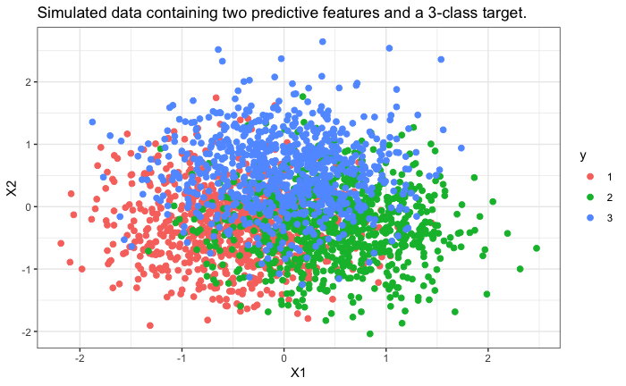

```r
batch_size <- 32
total_obs <- batch_size*100
train_obs <- batch_size*70

set.seed(123)
generated <- mlbench::mlbench.simplex(n = total_obs, d = 2, sd = 0.6)
X <- generated$x
y <- generated$classes

ggplot(data.frame(X, y), aes(X1, X2, color = y)) +
  geom_point(size = 2) +
  ggtitle("Simulated data containing two predictive features and a 3-class target.")
```

The following prepares our training and validation sets that we’ll use throughout:

```r
X <- generated$x
y <- to_categorical(generated$classes)[, 2:4]

# random sample
set.seed(123)
train_index <- sample(nrow(y), train_obs, replace = FALSE)
x_train <- X[train_index, ]
y_train <- y[train_index, ]
x_test <- X[-train_index, ]
y_test <- y[-train_index, ]
```

Also, to make our example more comparable, we’ll start our models with the same set of initial weights. If we did not do this then each model would start with different initialized weights which can cause different learning trajectories. By starting each model with the same weights we remove a large amount of the randomness in our models.

I create initial weights by training the data for one epoch and then using these weights as our initial weights:

```r
model <- keras_model_sequential() %>%
  layer_dense(units = 8, input_shape = ncol(x_train), activation = "relu",
              kernel_initializer = "he_uniform") %>%
  layer_dense(units = 3, activation = "softmax") %>%
  compile(
    optimizer = "sgd",
    loss = "categorical_crossentropy",
    metrics = "accuracy"
  )

history  <- model  %>%
  fit(x_train, y_train,
      batch_size = batch_size, epochs = 1,
      validation_data = list(x_test, y_test),
      verbose = 0)

initial_wts <- get_weights(model)[1:2]
```

## Effect of learning rate[^1]

As discussed in these slides ([ℹ️](http://bit.ly/dl-01#58)), neural networks attempt to find optimal weights using stochastic gradient descent (SGD). SGD is an optimization algorithm that estimates the error gradient for the current state of the model using examples from the training dataset, then updates the weights of the model using the backpropagation of errors algorithm, referred to as simply backpropagation.

The amount that the weights are updated during training is referred to as the step size or the *learning rate*. Specifically, the learning rate is a hyperparameter that typically ranges from [1e-1, 1e-6] (0.1 - 0.000001).

The learning rate hyperparameter controls the rate or speed at which the model learns. Specifically, it controls the amount of apportioned error that the weights of the model are updated with each time they are updated, such as at the end of each batch of training examples. Given a perfectly configured learning rate, the model will learn to best approximate the function given available resources (the number of layers and the number of nodes per layer) in a given number of training epochs (passes through the training data).

Generally, a large learning rate allows the model to learn faster, at the cost of arriving on a sub-optimal final set of weights. A smaller learning rate may allow the model to learn a more optimal or even globally optimal set of weights but may take significantly longer to train. At extremes, a learning rate that is too large will result in weight updates that will be too large and the performance of the model (such as its loss on the training dataset) will oscillate over training epochs. Oscillating performance is said to be caused by weights that diverge (are divergent). A learning rate that is too small may never converge or may get stuck on a suboptimal solution.

It is important to find a good value for the learning rate for your model on your training dataset. The learning rate may, in fact, be the most important hyperparameter to configure for your model. The learning rate will interact with many other aspects of the optimization process, and the interactions may be nonlinear. Nevertheless, in general, smaller learning rates will require more training epochs. Conversely, larger learning rates will require fewer training epochs. Further, smaller batch sizes are better suited to smaller learning rates given the noisy estimate of the error gradient. A traditional default value for the learning rate is 0.1 or 0.01, and this may represent a good starting point on your problem.

To demonstrate the effect of learning rate, let’s create a function that fits a two-layer densely connected neural network that uses a traditional SGD optimizer.

**Note**: In practice, the main code you change to adjust the learning rate is `optimizer_xxx(lr = ??)`.

```r
# Create model training function
train_model <- function(learning_rate, momentum = 0){
  model <- keras_model_sequential() %>%
    layer_dense(units = 8, input_shape = ncol(x_train), activation = "relu",
                kernel_initializer = "he_uniform") %>%
    layer_dense(units = 3, activation = "softmax")

  model %>% compile(
    optimizer = optimizer_sgd(lr = learning_rate, momentum = momentum),
    loss = "categorical_crossentropy",
    metrics = "accuracy"
  )

  # set same initial weights
  get_layer(model, index = 1) %>%
    set_weights(initial_wts)

  history <- model %>%
    fit(x_train, y_train,
        batch_size = batch_size,
        epochs = 50,
        validation_data = list(x_test, y_test),
        verbose = 0)

  as.data.frame(history) %>% mutate(lr = learning_rate, m = momentum)
}
```

Now we’ll iterate over various learning rates on a log scale and apply our model.

```r
# Model different learning rates
results <- data.frame()
learning_rates <- c(1e-0, 1e-1, 1e-2, 1e-3, 1e-4, 1e-5)
for (rate in learning_rates) {
  cat("Loss for model with learning rate = ", rate, ": ", sep = "")
  model_results <- train_model(rate)
  results <- rbind(results, model_results)

  # report results
  min_loss <- model_results %>%
    filter(metric == "loss", data == "validation") %>%
    summarize(best_loss = min(value, na.rm = TRUE) %>% round(3)) %>%
    pull()
  cat(min_loss, "\n", append = TRUE)
}
```

```
Loss for model with learning rate = 1: 0.744
Loss for model with learning rate = 0.1: 0.738
Loss for model with learning rate = 0.01: 0.757
Loss for model with learning rate = 0.001: 0.799
Loss for model with learning rate = 1e-04: 0.822
Loss for model with learning rate = 1e-05: 1.23
```

We can see that although the learning rate of 0.1 has the lowest loss score, there are a lot of oscillations in the behavior, which suggests an unstable model. We also see that the much smaller learning rates (1e-4, 1e-5) are learning at a much slower rate and are performing quite poorly.

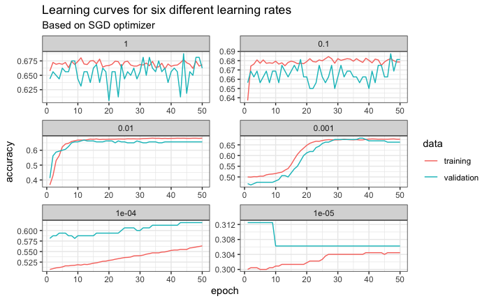

```r
results %>%
  filter(metric == "accuracy") %>%
  mutate(lr = fct_rev(as.factor(lr))) %>%
  ggplot(aes(epoch, value, color = data)) +
  geom_line() +
  facet_wrap(~ lr, ncol = 2, scales = "free") +
  ylab("accuracy") +
  ggtitle("Learning curves for six different learning rates",
          subtitle = "Based on SGD optimizer")
```

## Adding momentum

Training a neural network can be made easier by incorporating the history of the weight updates when determining the current update being made to the weights. Specifically, an exponentially weighted average of the prior updates to the weight can be included when the weights are updated. This change to stochastic gradient descent is called *momentum* and adds inertia to the update procedure, causing many past updates in one direction to continue in that direction in the future. The amount of inertia of past updates is controlled via the addition of a new hyperparameter, often referred to as the *momentum*.

Momentum can accelerate the training process along with smoothing the progression of the learning algorithm. We can adapt the example from the previous section to evaluate the effect of momentum with a fixed learning rate. In this case, we will use the learning rate 0.001.

**Note**: In practice, the main code you change to add momentum is `optimizer_sgd(lr = 0.01, momentum = ??)`.

```r
# Model different momentums
results <- data.frame()
momentums <- c(0, 0.25, 0.5, 0.75, 0.9, 0.99)
for (momentum in momentums) {
  cat("Loss for model with momentum = ", momentum, ": ", sep = "")
  model_results <- train_model(0.001, momentum)
  results <- rbind(results, model_results)

  # report results
  min_loss <- model_results %>%
    filter(metric == "loss", data == "validation") %>%
    summarize(best_loss = min(value, na.rm = TRUE) %>% round(3)) %>%
    pull()
  cat(min_loss, "\n", append = TRUE)
}
```

```
Loss for model with momentum = 0: 0.81
Loss for model with momentum = 0.25: 0.772
Loss for model with momentum = 0.5: 0.795
Loss for model with momentum = 0.75: 0.756
Loss for model with momentum = 0.9: 0.745
Loss for model with momentum = 0.99: 0.738
```

We can see that as the momentum increases, less epochs are required to reach convergence. In fact, including momentum $>$ 0.5 allows us to reach optimal performance in 20 or less epochs. Also, the highest momentum of 0.99 has a loss that matches the previous best model. And if you were to zoom into the plot of the model with momentum = 0.99, you would see that there is less variability than the previous model with a learning rate of 0.1 and no momentum. Consequently, adding momentum has allowed us to use a smaller learning rate, which is more careful in our loss trajectory, obtain a near-optimal loss and reduce variability in our model generalization!

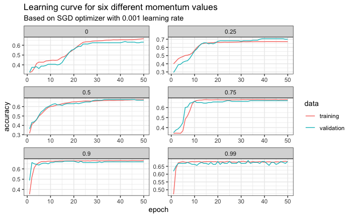

```r
results %>%
  filter(metric == "accuracy") %>%
  mutate(m = as.factor(m)) %>%
  ggplot(aes(epoch, value, color = data)) +
  geom_line() +
  facet_wrap(~ m, ncol = 2, scales = "free") +
  ylab("accuracy") +
  ggtitle("Learning curve for six different momentum values",
          subtitle = "Based on SGD optimizer with 0.001 learning rate")
```

We can also illustrate how momentum impacts the training of our weights. Since momentum speeds up the progression of our gradient descent, we should see faster updates in changes to the weights of our hidden layer nodes. The following code allows us to train a model with and without momentum and extract the weights of our first (and only) hidden layer.

```r
# create a model without momentum
model_no_momentum <- keras_model_sequential() %>%
  layer_dense(units = 8, input_shape = ncol(x_train), activation = "relu",
              kernel_initializer = "he_uniform") %>%
  layer_dense(units = 3, activation = "softmax") %>%
  compile(
    optimizer = optimizer_sgd(lr = 0.001, momentum = 0),
    loss = "categorical_crossentropy",
    metrics = "accuracy"
)

# set same initial weights
get_layer(model_no_momentum, index = 1) %>%
  set_weights(initial_wts)

# create a model with momentum
model_w_momentum <- keras_model_sequential() %>%
  layer_dense(units = 8, input_shape = ncol(x_train), activation = "relu",
              kernel_initializer = "he_uniform") %>%
  layer_dense(units = 3, activation = "softmax") %>%
  compile(
    optimizer = optimizer_sgd(lr = 0.001, momentum = 0.99),
    loss = "categorical_crossentropy",
    metrics = "accuracy"
  )

# set same initial weights
get_layer(model_w_momentum, index = 1) %>%
  set_weights(initial_wts)

# a function to extract the weights of the first layer
get_wts <- function(model, momentum) {
  get_weights(model)[[1]] %>%
    t() %>%
    as.data.frame() %>%
    mutate(
      node = row_number(),
      epochs = counter,
      momentum = momentum
    )
}
```

We can now iterate over 200 epochs and for each epoch we extract the first layer’s weights made by the SGD process.

```r
all_wts <- data.frame()
counter <- 1
for (i in rep(1, 200)) {

  history_no_momentum  <- model_no_momentum %>%
    fit(x_train, y_train,
        batch_size = batch_size,
        shuffle = FALSE,
        epochs = i,
        validation_data = list(x_test, y_test),
        verbose = FALSE)

  history_w_momentum  <- model_w_momentum  %>%
    fit(x_train, y_train,
        batch_size = batch_size,
        shuffle = FALSE,
        epochs = i,
        validation_data = list(x_test, y_test),
        verbose = FALSE)

  wts_no_momentum <- get_wts(model_no_momentum, momentum = FALSE)
  wts_w_momentum <- get_wts(model_w_momentum, momentum = TRUE)

  all_wts <- rbind(all_wts, rbind(wts_no_momentum, wts_w_momentum))
  counter <- counter + 1
}
```

We can now plot the progression of the weights over the 200 epochs. Recall that this model has 8 nodes in the hidden layer. This example plots the weights for feature `V2` for each of these eight nodes. The main thing to notice is that momentum allows the weights to react and have larger changes to their weights than SGD without momentum.

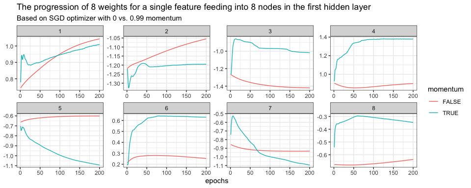

```r
all_wts %>%
  ggplot(aes(epochs, V2, color = momentum)) +
  geom_line() +
  ylab(NULL) +
  facet_wrap(~ node, scales = "free", ncol = 4) +
  ggtitle("The progression of 8 weights for a single feature feeding into 8 nodes in the first hidden layer",
          subtitle = "Based on SGD optimizer with 0 vs. 0.99 momentum")
```

## Alternative optimizers

Adding momentum to traditional SGD provides an alternative to the most basic SGD optimizer. The idea of momentum dates back to 1964[^2]; however, in more recent years there has been significant research that has identified other, useful gradient descent optimizers. This section will briefly discuss the main differences in these optimizers but for a robust and technical discussion regarding their difference I would check out [Sebastian Ruders article](https://ruder.io/optimizing-gradient-descent/index.html).

In addition to SGD and SGD with momentum, the most common optimizers that you will see are RMSprop (Root mean square prop) and Adam (Adaptive moment estimation).

**RMSprop** ([Hinton et al., 2012](http://www.cs.toronto.edu/~tijmen/csc321/slides/lecture_slides_lec6.pdf)) adapts the learning rate by dividing the learning rate for a weight by a running average of the magnitudes of recent gradients for that weight. Note that large fluctuations in gradients can cause exploding gradients and very small changes can cause vanishing gradients - both leading to unstable updates to the weights. RMSprop helps by reducing large and small oscilliations in updates to the weights by balancing changes in gradients via averaging recent gradients.

**Adam** is very similar to RMSprop in that it incorporates weighted average of recent gradients[^3]. However, it also includes an additional parameter that, essentially acts like momentum. So at its most basic, you can think of Adam as RMSprop + momentum.

There are other optimizers such as Adadelta, AdaMax, Nadam, AMSGrad - see https://keras.rstudio.com/reference/index.html#section-optimizers for all those available. However, SGD + momentum, RMSprop, and Adam are by far the most common and typically report the best performance.

The following are two GIFs from Sebastian Ruder’s blog post that provide a nice visual comparison of these different optimizers navigating a multi-dimensional loss surface.

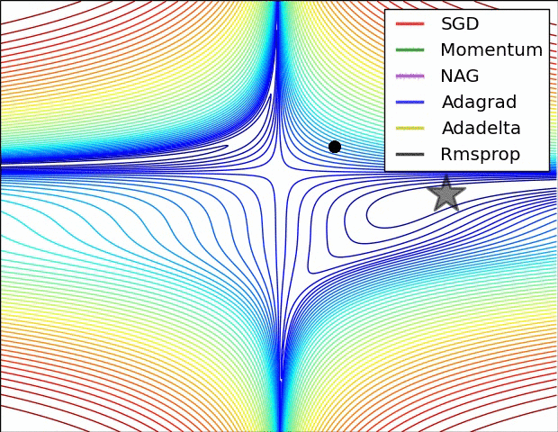

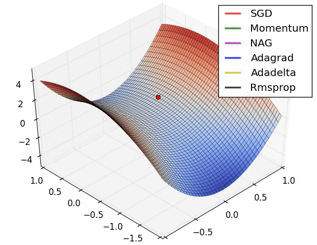

Let’s go ahead and compare SGD, SGD+momentum, RMSprop, and Adam on our toy data problem. Here, we create code that uses each optimizer and also extracts the weights of the first layer for each model (we’ll use this for a visual later on).

**Note**: In practice, the main code you change to adjust the gradient descent optimizer used is `optimizer_xxx()`.

```r
all_wts <- data.frame()
all_results <- data.frame()
optimizers <- c("sgd", "sgd_momentum", "rmsprop", "adam")

for (opt in optimizers) {

  # make sure all optimizers use the same learning rate
  if (opt == "sgd") {
    current_optimizer <- optimizer_sgd(lr = 0.001)
  } else if (opt == "sgd_momentum") {
    current_optimizer <- optimizer_sgd(lr = 0.001, momentum = 0.9)
  } else {
    current_optimizer <- opt
  }

  # create model architecture
  model <- keras_model_sequential() %>%
    layer_dense(units = 8, input_shape = ncol(x_train), activation = "relu",
                kernel_initializer = "he_uniform") %>%
    layer_dense(units = 3, activation = "softmax") %>%
    compile(
      optimizer = current_optimizer,
      loss = "categorical_crossentropy",
      metrics = "accuracy"
    )

  # same initial weights
  get_layer(model, index = 1) %>%
    set_weights(initial_wts)

  # iterate over each epoch and extract weights and results
  counter <- 1
  for (i in rep(1, 50)) {
    # train 1 epoch at a time
    history  <- model  %>%
      fit(x_train, y_train,
          batch_size = batch_size,
          shuffle = FALSE,
          epochs = i,
          validation_data = list(x_test, y_test),
          verbose = 0)

    # extract first layer weights
    model_wts <- get_weights(model)[[1]] %>%
      t() %>%
      as.data.frame() %>%
      mutate(
        node = row_number(),
        epochs = counter,
        optimizer = opt
      )

    # extract each epochs results
    model_results <- data.frame(history) %>%
      mutate(
        optimizer = opt,
        epoch = counter
        )

    all_wts <- rbind(all_wts, model_wts)
    all_results <- rbind(all_results, model_results)
    counter <- counter + 1
  }
}
```

[figure not shown]

```r
all_results %>%
  filter(metric == "accuracy") %>%
  ggplot(aes(epoch, value, color = data)) +
  geom_line() +
  facet_wrap(~ optimizer, ncol = 2) +
  ggtitle("Loss learning curve for different optimizers") +
  ylab("loss")
```

If we plot the changes in weights for the 8 hidden layer units we will see that SGD+momentum, RMSprop, and Adam all tend to change much quicker than SGD. We also see that in most cases, we see at least 2 of these optimizers (SGD+momentum, RMSprop, and Adam) have very similar patterns which highlights the similarity in nature of how these optimizers behave.

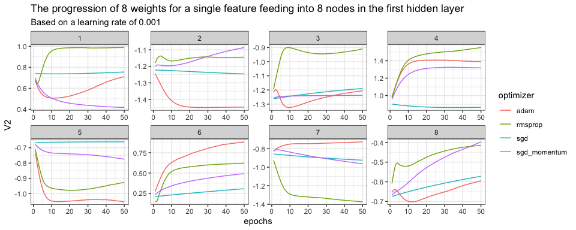

```r
all_wts %>%
  ggplot(aes(epochs, V2, color = optimizer)) +
  geom_line() +
  facet_wrap(~ node, scales = "free", ncol = 4) +
  ggtitle("The progression of 8 weights for a single feature feeding into 8 nodes in the first hidden layer",
          subtitle = "Based on a learning rate of 0.001")
```

## Common learning rate schedules

Rarely does a single, fixed learning rate achieve optimal performance. Instead, allowing the learning rate to vary over the training process often improves your model’s performance. The way in which the learning rate changes over time is referred to as the learning rate schedule or learning rate decay.

### Pre-specified learning rate decay

Perhaps the simplest learning rate schedule is to decrease the learning rate linearly from a large initial value to a small value. This allows large weight changes in the beginning of the learning process and small changes or fine-tuning towards the end of the learning process. This is most common for SGD optimizers, but all the keras optimizer functions have a built in `decay` argument. With learning rate decay, the learning rate is calculated each update (e.g. end of each mini-batch) as follows:

$$\text{lr} = \text{initial_lr} \times \frac{1}{1 + \text{decay} \times \text{iteration}}$$

Where `lr` is the learning rate for the current epoch, `initial_lr` is the initial learning rate specified as an argument to the SGD optimizer, `decay` is the decay rate which is greater than zero and iteration is the current update number.

Say we wanted to train a model with a learning rate of 0.01 for 50 epochs. The following illustrates how decay impacts the learning rate. Larger decay obviously results in larger learing rate reductions over time.

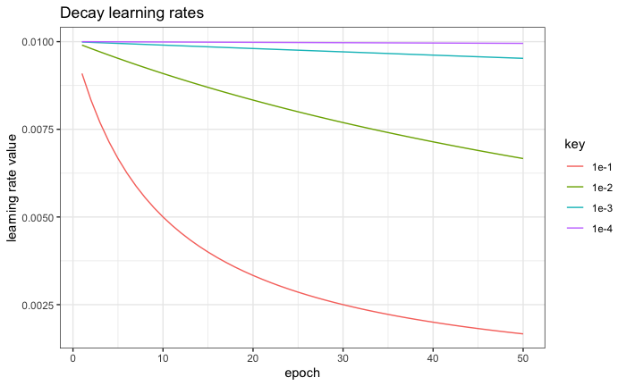

```r
decay_rates <- c(1e-1, 1e-2, 1e-3, 1e-4)
initial_rate <- 0.01
epoch <- 1:50

# function to compute decayed learning rate
compute_decay <- function(initial_rate, decay_rate, epoch) {
  initial_rate * 1 / (1 + decay_rate * epoch)
}

map_dfc(decay_rates, ~ compute_decay(initial_rate, ., epoch)) %>%
  rename(`1e-1` = "V1", `1e-2` = "V2", `1e-3` = "V3", `1e-4` = "V4") %>%
  mutate(epoch = epoch) %>%
  gather(key, value, -epoch) %>%
  ggplot(aes(epoch, value, color = key)) +
  geom_line() +
  ggtitle("Decay learning rates") +
  ylab("learning rate value")
```

```r
all_results <- data.frame()

for (decay_rate in c(1e-1, 1e-2, 1e-3, 1e-4)) {
  cat("Loss for model with decay = ", decay_rate, ": ", sep = "")

  # Create model training function
  model <- keras_model_sequential() %>%
    layer_dense(units = 8, input_shape = ncol(x_train), activation = "relu",
                kernel_initializer = "he_uniform") %>%
    layer_dense(units = 3, activation = "softmax")

  model %>% compile(
    optimizer = optimizer_sgd(lr = 0.01, momentum = 0.9, decay = decay_rate),
    loss = "categorical_crossentropy",
    metrics = "accuracy"
    )

  # set same initial weights
  get_layer(model, index = 1) %>%
    set_weights(initial_wts)

  history <- model %>%
    fit(x_train, y_train,
        batch_size = batch_size,
        epochs = 50,
        validation_data = list(x_test, y_test),
        verbose = 0)

  model_results <- data.frame(history) %>%
    mutate(decay = as.factor(decay_rate))

  all_results <- rbind(all_results, model_results)

  # report results
  min_loss <- model_results %>%
    filter(metric == "loss", data == "validation") %>%
    summarize(best_loss = min(value, na.rm = TRUE) %>% round(3)) %>%
    pull()
  cat(min_loss, "\n", append = TRUE)
}
```

```
Loss for model with decay = 0.1: 0.814
Loss for model with decay = 0.01: 0.754
Loss for model with decay = 0.001: 0.741
Loss for model with decay = 1e-04: 0.744
```

Recall, that in the first section a learning rate of 0.1 had the optimal loss but the accuracy learning curve had a lot of variability. As you can see, as we add larger decay values the variability reduces. In this example we see a reduction in model performance from our original model; however, in some scenarios we can see performance improvements.

[figure not shown]

```r
all_results %>%
  filter(metric == "accuracy") %>%
  ggplot(aes(epoch, value, color = data)) +
  geom_line() +
  facet_wrap(~ decay, ncol = 2) +
  ggtitle("Loss curve for different decay rates") +
  ylab("loss")
```

### Automated learning rate decay

However, rather than pre-specify when the learning rate should reduce, automated learning rate decay can allow the data to tell your training process when to reduce. As demonstrated in https://rstudio-conf-2020.github.io/dl-keras-tf/notebooks/01-ames.nb.html we use callbacks automatically reduce the learning rate upon plateaus and we can specify the amount of reduction (`factor`) and how long to wait with no model improvement before reducing (`patience`). This also allows us to apply this method to any of the gradient descent optimizers.

```r
model <- keras_model_sequential() %>%
  layer_dense(units = 8, input_shape = ncol(x_train), activation = "relu",
              kernel_initializer = "he_uniform") %>%
  layer_dense(units = 3, activation = "softmax")

model %>% compile(
  optimizer = optimizer_sgd(lr = 0.01, momentum = 0.9),
  loss = "categorical_crossentropy",
  metrics = "accuracy"
  )

  # set same initial weights
get_layer(model, index = 1) %>%
  set_weights(initial_wts)

history <- model %>%
  fit(x_train, y_train,
      batch_size = batch_size,
      epochs = 50,
      validation_data = list(x_test, y_test),
      callback = callback_reduce_lr_on_plateau(factor = 0.1, patience = 3),
      verbose = 0)
```

When using callbacks, our model’s history results will track the changes in learning rate so we can see the progression.

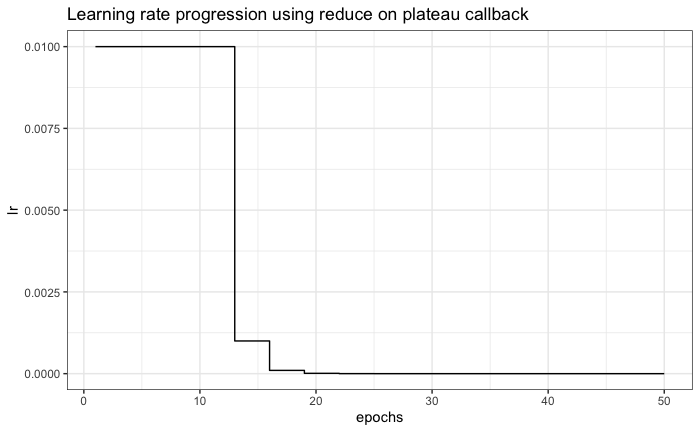

```r
data.frame(history$metrics) %>%
  mutate(epochs = row_number()) %>%
  ggplot(aes(epochs, lr)) +
  geom_step() +
  ggtitle("Learning rate progression using reduce on plateau callback")
```

The factor to reduce by and the patience can have varying effects on performance. If you reduce by a factor too large and/or too early then you risk slowing down the gradient descent progression and the model may never find an optimal loss. If you reduce by a factor too small or too late then you run the risk of maintaining a learing rate that is too large and having an unstable model.

```r
all_results <- data.frame()

for (patience in c(2, 5, 15, 30)) {
  cat("Loss for model with patience value = ", patience, ": ", sep = "")

  # Create model training function
  model <- keras_model_sequential() %>%
    layer_dense(units = 8, input_shape = ncol(x_train), activation = "relu",
                kernel_initializer = "he_uniform") %>%
    layer_dense(units = 3, activation = "softmax")

  model %>% compile(
    optimizer = optimizer_sgd(lr = 0.01, momentum = .9),
    loss = "categorical_crossentropy",
    metrics = "accuracy"
    )

  # set same initial weights
  get_layer(model, index = 1) %>%
    set_weights(initial_wts)

  history <- model %>%
    fit(x_train, y_train,
        batch_size = batch_size,
        epochs = 50,
        validation_data = list(x_test, y_test),
        callback = callback_reduce_lr_on_plateau(factor = 0.1, patience = patience),
        verbose = 0)

  model_results <- data.frame(history) %>%
    mutate(patience = as.factor(patience))

  all_results <- rbind(all_results, model_results)

  # report results
  min_loss <- model_results %>%
    filter(metric == "loss", data == "validation") %>%
    summarize(best_loss = min(value, na.rm = TRUE) %>% round(3)) %>%
    pull()
  cat(min_loss, "\n", append = TRUE)
}
```

```
Loss for model with patience value = 2: 0.743
Loss for model with patience value = 5: 0.741
Loss for model with patience value = 15: 0.741
Loss for model with patience value = 30: 0.742
```

The results illustrate the effect of various patience periods on accuracy.

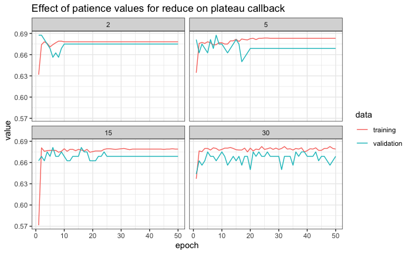

```r
all_results %>%
  filter(metric == "accuracy") %>%
  ggplot(aes(epoch, value, color = data)) +
  geom_line() +
  facet_wrap(~ patience, ncol = 2) +
  ggtitle("Effect of patience values for reduce on plateau callback")
```

[^1]: Adapted from Better Deep Learning by Jason Brownlee.
[^2]: https://www.researchgate.net/publication/243648538_Some_methods_of_speeding_up_the_convergence_of_iteration_methods
[^3]: More specifically, the exponentially decaying average of past squared gradients